# Practical Machine Learning Final Project

Manfred Herdt

10/6/2020

## Background

Using devices such as Jawbone Up, Nike FuelBand, and Fitbit it is now possible to collect a large amount of data about personal activity relatively inexpensively. These type of devices are part of the quantified self movement – a group of enthusiasts who take measurements about themselves regularly to improve their health, to find patterns in their behavior, or because they are tech geeks. One thing that people regularly do is quantify how much of a particular activity they do, but they rarely quantify how well they do it.

## Goal

The goal of your project is to predict the manner in which they did the exercise. This is the “classe” variable in the training set. You may use any of the other variables to predict with. You should create a report describing how you built your model, how you used cross validation, what you think the expected out of sample error is, and why you made the choices you did. You will also use your prediction model to predict 20 different test cases.

## Data

Data

The training data for this project are available here:

https://d396qusza40orc.cloudfront.net/predmachlearn/pml-training.csv

The test data are available here:

https://d396qusza40orc.cloudfront.net/predmachlearn/pml-testing.csv

```r
library(tidyverse)
library(naniar)
library(randomForest)
library(caret)
library(rpart)
library(rattle)
```

```r
valid <- read.csv("https://d396qusza40orc.cloudfront.net/predmachlearn/pml-testing.csv",na.strings=c("NA","#DIV/0!",""))
train <- read.csv("https://d396qusza40orc.cloudfront.net/predmachlearn/pml-training.csv",na.strings=c("NA","#DIV/0!",""))
```

## Visual Analysis and preprocessing on the training set.

#### Miss Map. As we can see, over 60 % of the data is missing, and will be dropped.

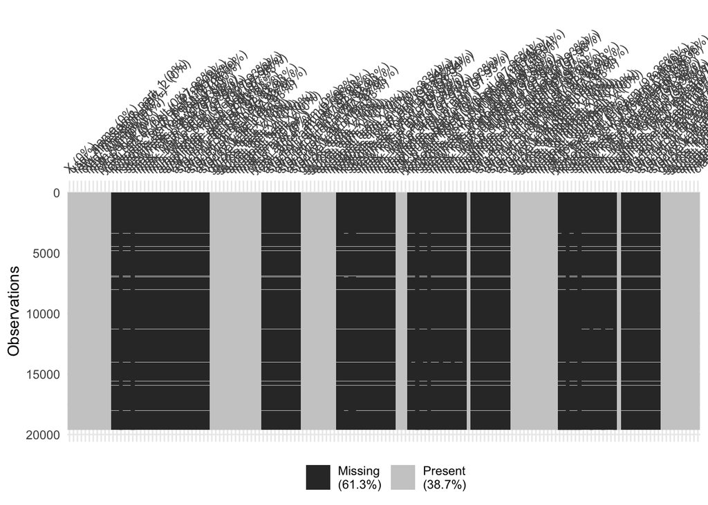

```r
naniar::vis_miss(train,warn_large_data=FALSE)
```

```r
df <- train %>% mutate(set = "TRAIN", problem_id = "NA") %>% rbind(valid %>% mutate(set = "VALID", classe = "NA"))

df <- df %>% mutate_if(is.character, as.factor)

x_seg <- naniar::miss_var_summary(df) %>% filter(pct_miss < .9) %>% select(variable)

df_x <- df %>% select(as.character(x_seg$variable)) %>% select(!contains(c("timestamp","X", "user_name","classe")))

df_y <- df %>% select(c("classe","set"))
```

## Split the data in test/training and valid set. Splitting the training data into two sets.

```r
df_x_train <- df_x %>% filter(set == "TRAIN")
df_y_train <- df_y %>% filter(set == "TRAIN")

df_x_valid <- df_x %>% filter(set == "VALID")
df_y_valid <- df_y %>% filter(set == "VALID")



set.seed(234548) # Set Seed so that same sample can be reproduced in future also
# Now Selecting 75% of data as sample from total 'n' rows of the data
sample <- sample.int(n = nrow(train), size = floor(.75*nrow(train)), replace = F)

df_x2 <- cbind(df_x_train,df_y_train %>% select(!contains("set")))

x_train <- df_x2[sample, ]
x_test  <- df_x2[-sample, ]

x_train_new <- x_train %>% select(!contains(c("problem_id","set"))) %>% mutate(classe= droplevels(classe))

x_test_new  <- x_test %>% select(!contains(c("problem_id","set"))) %>% mutate(classe= droplevels(classe))

df_valid2 <- cbind(df_x_valid%>%select(!contains("set")),df_y_valid)

df_valid2 <- df_valid2 %>% select(!contains(c("set","problem_id")))
```

First Algorithm Random Forest

```r
controlRF <- trainControl(method="cv", number=3, verboseIter=FALSE)

rb1 <- randomForest(classe~ .,data=x_train_new,trControl=controlRF)
```

## Checking the test on the training error. Because its in sample, the accuracy is very high. Need to test on the test set.

```r
predictionB0 <- predict(rb1, newdata = x_train_new, type = "class")
cmrf_train <- confusionMatrix(predictionB0, x_train_new$classe)
print(cmrf_train)
```

```
## Confusion Matrix and Statistics
##
##           Reference
## Prediction    A    B    C    D    E
##          A 4212    0    0    0    0
##          B    0 2803    0    0    0
##          C    0    0 2589    0    0
##          D    0    0    0 2392    0
##          E    0    0    0    0 2720
##
## Overall Statistics
##
##                Accuracy : 1
##                  95% CI : (0.9997, 1)
##     No Information Rate : 0.2862
##     P-Value [Acc > NIR] : < 2.2e-16
##
##                   Kappa : 1
##
##  Mcnemar's Test P-Value : NA
##
## Statistics by Class:
##
##                      Class: A Class: B Class: C Class: D Class: E
## Sensitivity            1.0000   1.0000   1.0000   1.0000   1.0000
## Specificity            1.0000   1.0000   1.0000   1.0000   1.0000
## Pos Pred Value         1.0000   1.0000   1.0000   1.0000   1.0000
## Neg Pred Value         1.0000   1.0000   1.0000   1.0000   1.0000
## Prevalence             0.2862   0.1905   0.1759   0.1625   0.1848
## Detection Rate         0.2862   0.1905   0.1759   0.1625   0.1848
## Detection Prevalence   0.2862   0.1905   0.1759   0.1625   0.1848
## Balanced Accuracy      1.0000   1.0000   1.0000   1.0000   1.0000
```

```r
predictionB1 <- predict(rb1, newdata = x_test_new, type = "class")
cmrf <- confusionMatrix(predictionB1, x_test_new$classe)
print(cmrf)
```

```
## Confusion Matrix and Statistics
##
##           Reference
## Prediction    A    B    C    D    E
##          A 1368    4    0    0    0
##          B    0  990    1    0    0
##          C    0    0  832    5    0
##          D    0    0    0  818    1
##          E    0    0    0    1  886
##
## Overall Statistics
##
##                Accuracy : 0.9976
##                  95% CI : (0.9957, 0.9987)
##     No Information Rate : 0.2788
##     P-Value [Acc > NIR] : < 2.2e-16
##
##                   Kappa : 0.9969
##
##  Mcnemar's Test P-Value : NA
##
## Statistics by Class:
##
##                      Class: A Class: B Class: C Class: D Class: E
## Sensitivity            1.0000   0.9960   0.9988   0.9927   0.9989
## Specificity            0.9989   0.9997   0.9988   0.9998   0.9998
## Pos Pred Value         0.9971   0.9990   0.9940   0.9988   0.9989
## Neg Pred Value         1.0000   0.9990   0.9998   0.9985   0.9998
## Prevalence             0.2788   0.2026   0.1698   0.1680   0.1808
## Detection Rate         0.2788   0.2018   0.1696   0.1667   0.1806
## Detection Prevalence   0.2797   0.2020   0.1706   0.1669   0.1808
## Balanced Accuracy      0.9994   0.9979   0.9988   0.9962   0.9993
```

```r
#predictionvalid <- predict(rb1, newdata = df_valid2, type = "class")
```

### Accuracy : 0.9976, so we expect the out-of-sample error to be 0.0024.

## Decision Trees

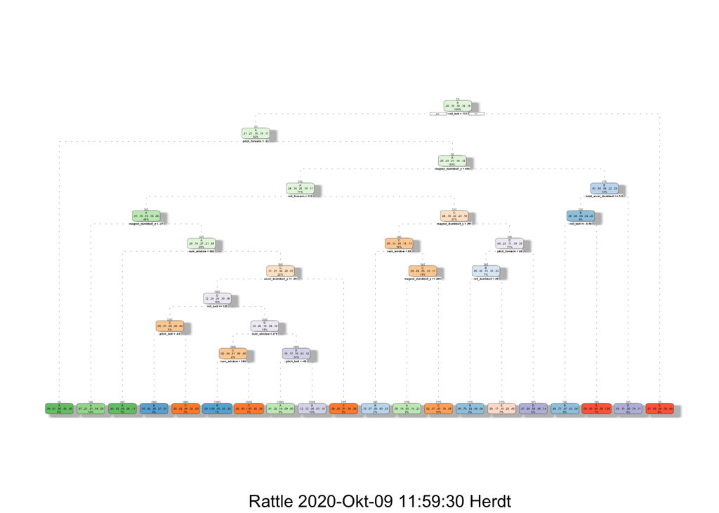

```r
set.seed(12321)
DecTree <- rpart(classe ~ ., data=x_train_new, method="class")


fancyRpartPlot(DecTree)
```

```r
predictree <- predict(DecTree, x_test_new, type = "class")
cmtree <- confusionMatrix(predictree, x_test_new$classe)
print(cmtree)
```

```
## Confusion Matrix and Statistics
##
##           Reference
## Prediction    A    B    C    D    E
##          A 1244  235   39   96   71
##          B   29  535   33   20   81
##          C    2   49  652  121   55
##          D   77  125   54  548  113
##          E   16   50   55   39  567
##
## Overall Statistics
##
##                Accuracy : 0.7228
##                  95% CI : (0.71, 0.7353)
##     No Information Rate : 0.2788
##     P-Value [Acc > NIR] : < 2.2e-16
##
##                   Kappa : 0.6477
##
##  Mcnemar's Test P-Value : < 2.2e-16
##
## Statistics by Class:
##
##                      Class: A Class: B Class: C Class: D Class: E
## Sensitivity            0.9094   0.5382   0.7827   0.6650   0.6392
## Specificity            0.8754   0.9583   0.9443   0.9096   0.9602
## Pos Pred Value         0.7383   0.7665   0.7418   0.5976   0.7799
## Neg Pred Value         0.9615   0.8909   0.9551   0.9308   0.9234
## Prevalence             0.2788   0.2026   0.1698   0.1680   0.1808
## Detection Rate         0.2536   0.1091   0.1329   0.1117   0.1156
## Detection Prevalence   0.3435   0.1423   0.1792   0.1869   0.1482
## Balanced Accuracy      0.8924   0.7483   0.8635   0.7873   0.7997
```

## we will choose the Random Forrest.

## Now we use the Random Forest to predict the 20 Problem ids.

```r
predictionvalid <- predict(rb1, newdata = df_valid2, type = "class")
print(predictionvalid)
```

```
##  1  2  3  4  5  6  7  8  9 10 11 12 13 14 15 16 17 18 19 20
##  B  A  B  A  A  E  D  B  A  A  B  C  B  A  E  E  A  B  B  B
## Levels: A B C D E
```